# Dimension Reduction Examples in R

W. Evan Johnson

2025-07-27

## Set up: load these packages!

```r
library(umap)
library(DT)
library(tidyverse)
library(SummarizedExperiment)
library(TBSignatureProfiler)
```

## Data Structures

A data structure is a particular way of organizing data in a computer so that it can be used effectively. The idea is to reduce the space and time complexities of different tasks.

Data structures in R programming are tools for holding multiple values, variables, and sometimes functions

**Please think very carefully about the way you manage and store your data!** This can make your life much easier and make your code and data cleaner and more portable!

### Data Frames

A large proportion of data analysis challenges start with data stored in a data frame. For example, we stored the data for our motivating example in a data frame. You can access this dataset by loading `TBNanostring.rds` object in R:

```r
TBnanostring <- readRDS("TBnanostring.rds")
```

In RStudio we can view the data with the `View` function:

```r
View(TBnanostring)
```

Or in RMarkdown you can use the `datatable` function from the `DT` package:

```r
datatable(TBnanostring)
```

|  | TB_Status | AGAP9 | AIRE | ANKRD22 | APOL1 | APOL6 | ATP1A1 | BATF2 | BCL6 | BLK | C16orf7 | C1QB | C1QC | C4ORF18 | C5 | CCDC14 | CCDC78 | CCR6 | CD1C | CD79A | CD79B | CIRBP | CTSA | CXCR5 | CXorf40B | CYP4F3 | DARS2 | DERA | DUSP3 | … |
| --- | --- | --- | --- | --- | --- | --- | --- | --- | --- | --- | --- | --- | --- | --- | --- | --- | --- | --- | --- | --- | --- | --- | --- | --- | --- | --- | --- | --- | --- | --- |
| Sample_1 | TB | -0.3567952891613851 | -0.2428400750618191 | 1.207905558493485 | 1.555417591919483 | 1.253195633963252 | -1.19773967725765 | 1.267449740074419 | 1.44405564668365 | 0.08830775445314894 | 2.019266536890396 | 0.7516975319176218 | 0.3728128299227613 | -1.044097012784921 | -0.6537817263494731 | -0.6655872996869874 | 0.3941787796749492 | -0.731969022018938 | 0.2519854285556507 | 0.1100454335247583 | 0.02071439218469675 | -0.3212363894966508 | -1.149180848797646 | 0.3352513020122072 | -0.5414855353359561 | 1.274072363654428 | -0.1299396035972255 | -2.397303286864058 | 0.2299788779102083 | … |
| Sample_2 | TB | -0.5855965092374802 | -1.306416297601576 | 1.216041831341325 | 0.5208883402769555 | -0.07293285737957687 | -1.090330219535047 | 0.3970186823102559 | 0.5046354934802626 | -1.668252626535817 | 1.699008243667597 | 1.266415983002439 | 1.397989287308514 | 0.7745526015112829 | 0.5992139442150497 | -1.543550285725023 | 0.004670462482051654 | -1.484418435922324 | 0.3703776259266084 | -2.017855314157253 | -1.50285848270686 | -1.029017144667262 | 1.144979693267663 | -1.591693600854994 | -0.650163550455721 | 0.9066523154368646 | -0.9552105910616149 | 0.5002664813531675 | 1.186088490147909 | … |
| Sample_3 | TB | -0.7078443755887588 | 0.4544570754679451 | 0.1840317405129417 | 0.9494341145965206 | 1.644055869109122 | 0.502818498776224 | 0.5904435779994958 | 0.2033804354046358 | -1.052170149038109 | 0.1905297652957624 | 0.1035590670298391 | 0.002535352876393561 | 1.497504717120949 | 1.111576237536498 | -0.8580099443371357 | -0.675949760725112 | -0.9478361361919522 | -1.131327775946374 | -0.9823028457157846 | -1.345413654355336 | -0.550787253089989 | 1.197782679137242 | -0.9561950288944006 | -0.4921720574098309 | 0.1244443090172449 | -0.7795466235788089 | -0.6559051562414868 | 0.6930788083993142 | … |
| Sample_4 | TB | -1.031494667575215 | -0.600953084668492 | 1.628997686518667 | 2.075581508023125 | 1.823098909982189 | -1.307260034784574 | 1.376982284915563 | 1.847995219384217 | -1.361940589988246 | 2.524736151391167 | 0.755247441115648 | 0.3101495804997122 | 1.163219685390775 | -1.211930639904139 | -1.689793585506124 | 0.5001794710387819 | -1.10819211956498 | -1.193657466264923 | -1.112137911596951 | -1.33186843527569 | -0.7038541523416637 | 0.5308060675652948 | -1.099250316818298 | -0.9543184887761932 | 0.4315414607187606 | -2.026026663896097 | -0.7080736613811327 | 2.244592066682114 | … |
| Sample_5 | TB | 0.9067240290496833 | -0.1348924583178322 | -1.246894792845696 | -1.909669345338767 | -1.884188394186358 | 0.5920268788386729 | -1.565009666862524 | 0.2623956965346229 | 0.820643298328746 | -0.6990454334548679 | -1.083580214103867 | -0.6644456998932498 | 1.952931401028057 | 0.2914324531183866 | 0.8068929732375072 | 0.3842083479338066 | 1.088422222794646 | 1.249115329733536 | 0.9866711547788964 | 0.9104379020429241 | 0.3096601100166029 | -0.1476334293752958 | 0.8238985049492284 | 0.5323003625478224 | -0.004769889750576167 | 0.6436695769010405 | 1.619851589921788 | 0.2219999392611381 | … |
| Sample_6 | TB | -1.83851797105418 | -0.1280090784823144 | 0.8316545568380391 | 1.545006176944255 | 0.7208395835658897 | -1.791034149237936 | 1.348357662074938 | 1.147202275569644 | -1.456526606519168 | 1.041255815744687 | 1.063157431296947 | 0.5869006815956217 | 0.1411222404339071 | 0.4314394118862134 | -1.099506015673339 | -1.109208522979346 | -0.8445763418653442 | -1.513864896772926 | -1.772087484684398 | -1.745419947274584 | -1.684252106610131 | 0.7902316529489498 | -1.834249440392554 | -2.109834739591115 | -0.1924586523473725 | -2.314056444090808 | -0.4059249727368296 | 1.014671428328334 | … |
| Sample_7 | TB | 0.05707858493869713 | -1.069854815292915 | 1.189719488865898 | 0.5402351126887245 | 0.7031789856392341 | -0.3818936938393588 | 0.3827145880386386 | 0.8829995825248439 | -0.7671685890744196 | 0.4830399349631236 | -0.5537144551966539 | -0.2835549663622023 | 0.4692120867406758 | -0.1797230425235556 | -0.5594571787153348 | 0.6181745797269812 | -0.9181663430658387 | -0.4642661301471259 | -0.5040647744700524 | -0.4370386919607227 | 1.016509577140669 | -0.1904821171775223 | -0.4032354212848691 | 0.4023719199114419 | 2.167110090536964 | -0.1801868239153136 | -0.6521957193814021 | -0.6645721100370381 | … |
| Sample_8 | TB | -1.883431240167627 | -0.3126381478393918 | 1.50828543722368 | 0.640879601402786 | 2.013017835850941 | -2.172355556174608 | 1.538902864967792 | 0.1354778929013789 | -1.597201021442571 | 1.001035121012908 | 0.9860346466697851 | 0.5004784541589815 | 2.048798646933404 | 0.415294373849733 | -1.257503350664715 | 0.06130851992982272 | -1.950098254224667 | -0.9548917291379766 | -2.009115587082828 | -2.205184564841673 | -1.395130230563012 | -0.6037633826390437 | -2.0294814108926 | -0.01456281910193487 | 0.3890934324866815 | -1.338975631149127 | -2.174430969936838 | 0.2151384800074111 | … |
| Sample_9 | TB | -1.420386185986475 | 0.515383912267111 | 2.610736305246323 | 2.290270059911697 | 2.319317923810889 | -1.455672628594579 | 2.579743829161462 | 0.6216968649724902 | -1.825897128894175 | 1.524702707602241 | 2.241698148500488 | 2.236351022920394 | 0.6611313274262467 | 1.71147702236411 | -0.8662274369939202 | 0.1874593189327216 | -1.231761445517768 | -2.792921964006282 | -1.568631440608613 | -2.074186261695775 | -1.376791283756899 | 1.411948406363706 | -1.644780614603827 | -1.646583654183484 | 0.009585044330324512 | -1.40905778549676 | -1.238000970587481 | 2.511139673095197 | … |
| Sample_10 | TB | -1.38629357623991 | 0.4353941807468526 | 1.785281524644318 | 1.802817415598585 | 2.251563891720713 | -1.607405208737903 | 1.837433876454194 | 1.030657791301887 | -1.470958653056692 | 1.102376348186373 | 1.202236468820842 | 1.277364549709066 | 0.2999661591271855 | 1.423920466821625 | -1.199193801551537 | -0.1949666172492625 | -1.335260518417128 | -1.314502010055313 | -1.214617477447743 | -1.809972298861618 | -1.88626746616501 | 0.4951357059648722 | -1.568400619543112 | -1.519260006773639 | 0.596428364048616 | -1.774390528190914 | -1.811676935566049 | 1.057072629238347 | … |

[output cut: 169 more lines]

You will notice that the TB status is found in the first column of the data frame, followed by the genes in the subsequent columns. The rows represent each individual patient.

### Advanced Data Structures

There are advanced R data structures, **S3** and **S4** class objects, that can facilitate object orientated programming. One useful example of an S4 class data structure is the **SummarizedExperiment** object.

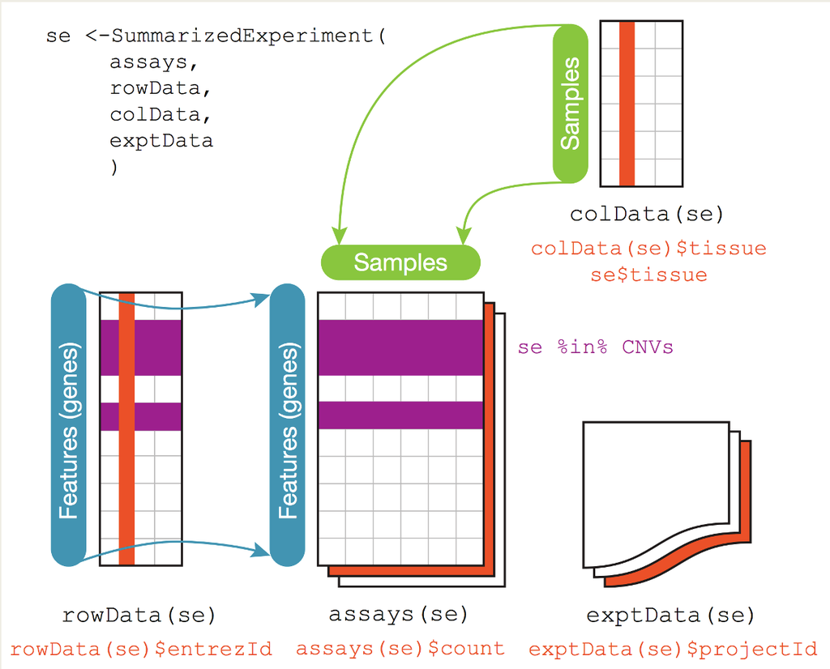

## Dimension Reduction

### PCA Example

Here is the code for applying PCA to the Nanostring dataset:

```r
pca_out <- prcomp(TBnanostring[,-1])
names(pca_out)
```

```
## [1] "sdev"     "rotation" "center"   "scale"    "x"
```

Here is a summary of the explained variation from the PCA:

```r
round(pca_out$sdev^2/sum(pca_out$sdev^2),3)
```

```
##   [1] 0.468 0.073 0.058 0.037 0.033 0.024 0.021 0.018 0.016 0.015 0.013 0.013
##  [13] 0.011 0.010 0.009 0.009 0.008 0.008 0.008 0.007 0.007 0.007 0.006 0.006
##  [25] 0.006 0.006 0.005 0.005 0.005 0.004 0.004 0.004 0.004 0.003 0.003 0.003
##  [37] 0.003 0.003 0.003 0.003 0.002 0.002 0.002 0.002 0.002 0.002 0.002 0.002
##  [49] 0.002 0.002 0.002 0.002 0.001 0.001 0.001 0.001 0.001 0.001 0.001 0.001
##  [61] 0.001 0.001 0.001 0.001 0.001 0.001 0.001 0.001 0.001 0.001 0.001 0.001
##  [73] 0.001 0.001 0.001 0.001 0.000 0.000 0.000 0.000 0.000 0.000 0.000 0.000
##  [85] 0.000 0.000 0.000 0.000 0.000 0.000 0.000 0.000 0.000 0.000 0.000 0.000
##  [97] 0.000 0.000 0.000 0.000 0.000 0.000 0.000 0.000 0.000 0.000 0.000
```

And the cumulative variation explained:

```r
round(cumsum(pca_out$sdev^2)/sum(pca_out$sdev^2),3)
```

```
##   [1] 0.468 0.541 0.599 0.636 0.669 0.694 0.714 0.732 0.747 0.762 0.776 0.788
##  [13] 0.799 0.810 0.819 0.827 0.836 0.844 0.851 0.859 0.866 0.872 0.879 0.885
##  [25] 0.891 0.896 0.902 0.906 0.911 0.915 0.919 0.923 0.927 0.931 0.934 0.937
##  [37] 0.940 0.943 0.946 0.949 0.951 0.953 0.956 0.958 0.960 0.962 0.964 0.966
##  [49] 0.967 0.969 0.971 0.972 0.974 0.975 0.976 0.978 0.979 0.980 0.981 0.982
##  [61] 0.983 0.984 0.985 0.986 0.987 0.988 0.988 0.989 0.990 0.990 0.991 0.992
##  [73] 0.992 0.993 0.993 0.994 0.994 0.995 0.995 0.995 0.996 0.996 0.997 0.997
##  [85] 0.997 0.997 0.998 0.998 0.998 0.998 0.998 0.999 0.999 0.999 0.999 0.999
##  [97] 0.999 0.999 1.000 1.000 1.000 1.000 1.000 1.000 1.000 1.000 1.000
```

Now we will make a dataframe with the PCs for later use!

```r
pca_reduction <- as.data.frame(pca_out$x)
pca_reduction$Condition <- as.factor(TBnanostring$TB_Status)
datatable(pca_reduction)
```

|  | PC1 | PC2 | PC3 | PC4 | PC5 | PC6 | PC7 | PC8 | PC9 | PC10 | PC11 | PC12 | PC13 | PC14 | PC15 | PC16 | PC17 | PC18 | PC19 | PC20 | PC21 | PC22 | PC23 | PC24 | PC25 | PC26 | PC27 | PC28 | PC29 | … |
| --- | --- | --- | --- | --- | --- | --- | --- | --- | --- | --- | --- | --- | --- | --- | --- | --- | --- | --- | --- | --- | --- | --- | --- | --- | --- | --- | --- | --- | --- | --- |
| Sample_1 | -6.217285619912235 | -2.60510012247689 | 1.314995599651234 | -2.222912510120137 | -3.847034204410479 | -3.492482769047264 | -1.710302669240495 | 0.2753538581286465 | -1.81349655510807 | -1.20032542988247 | -0.8808990186810232 | -0.1219053266185646 | -1.582552611013441 | 0.04242755309370993 | -0.7944259158658368 | -1.307819791080596 | -0.5852399567130402 | -0.2913746772345319 | 0.255517844037095 | 0.4704749235748164 | -0.1439851627874991 | 1.264339838302798 | -1.422892653307131 | -1.165335326219951 | 0.5820134485479064 | -0.357063162085885 | -0.2162548809175792 | 0.0169614022197598 | -0.1581733782386735 | … |
| Sample_2 | -7.327294251186226 | 3.764234360237181 | -4.968004401929236 | -3.042055621513066 | 0.6532653627399608 | 1.503497099757077 | -0.02205177837328351 | -1.356162603441423 | -1.228226578953761 | -1.621593441188536 | 2.206824620735722 | -0.3617561682352549 | 1.229309031487845 | 0.1943927225103783 | 0.4562442656365291 | 0.1943418826641787 | 0.2984382560873677 | -1.640513759189793 | 0.2175982110324098 | -0.6195920755190083 | -0.5348246604542827 | 0.2708144398328022 | -0.05671070764382209 | -0.5231468963824325 | 0.4391513684270693 | 0.7453528273227139 | 1.353052809694473 | -1.227958471348609 | -0.6628706887075635 | … |
| Sample_3 | -5.375213295990322 | -0.8862508482409807 | 2.241298160038888 | 0.5057575342741214 | 2.43278384976374 | -0.1030506481417787 | 1.333842541984344 | -1.894695361759197 | 0.533271897907917 | -0.2865686861976124 | 1.823151976887365 | -0.6482705353870599 | -0.5404989184463721 | -1.054640200454541 | -0.7577158439740052 | -0.1558294443995044 | 0.7835539346057836 | 1.31546691900776 | -0.666412132286823 | -0.04494433481059044 | -0.6285763405954343 | 0.8332180834019672 | 0.2939728077350727 | -0.2493923093077162 | -0.6654080805899466 | 0.6149917950920416 | -0.2557928344093389 | 0.6309408067401167 | -0.7221634080399878 | … |
| Sample_4 | -11.22400568483464 | 1.329128520222887 | 1.098614164850794 | -2.651950669799336 | -1.112211279400205 | -1.333861976759646 | 0.600594168213873 | -2.529877123050234 | -1.559959337759625 | 0.5903462931099973 | 0.5527820512095092 | 1.594194889362787 | -1.035454026685187 | -0.8959283020847278 | -0.588269860864934 | -0.3284223481933608 | 0.2213610925902099 | -0.1237248065914762 | 1.657702768204408 | -0.5400600916871879 | -1.021158550523765 | 0.6795280119532545 | -0.620835236760113 | -0.09750841916065105 | -0.2849688929662986 | 0.243834620531695 | -0.8954776158702427 | 0.03134943456673217 | -0.4473950460410618 | … |
| Sample_5 | 6.667676591112093 | 3.466185794877578 | -2.027080167283322 | -0.5332913146353484 | 2.557410601173757 | 2.088370679933787 | 1.852993629889534 | 0.4534965874736283 | -1.52006814429432 | -0.5151266443808681 | -1.458404813820251 | -2.244486748868975 | 1.014578189887549 | -0.756100964858161 | 1.169728308902731 | -0.6004849066658219 | 0.0505395914962319 | -1.029775788746977 | -0.7231368025192616 | -0.01721701313979343 | -0.165612011046603 | -0.8353166573891407 | 0.6968177362575824 | 0.08935576179747542 | 0.330111167873954 | -0.6101047830553852 | 0.6641380850424149 | 1.424166712762261 | -0.6206860223444759 | … |
| Sample_6 | -12.6852641655278 | 0.9622367093930663 | -0.655716337402723 | -0.850591017110856 | -1.686000607565833 | -0.6764981074211203 | 0.8939391326844491 | 1.967163937693482 | -1.353749170368481 | 2.174956259492719 | 0.7448945868843634 | 0.778496229558876 | -0.8714860609901793 | -1.828129300968346 | 1.357658819698927 | 0.4937324347293304 | -0.1422525783195462 | -1.787279764503481 | -0.01331502750203767 | -0.3698552455284611 | -0.5662953498264083 | -0.09320847600807715 | -0.7996701365393587 | -0.1930695654776435 | -0.3794634854082818 | 0.4709059907311362 | 0.2766861308814631 | 0.804155495066752 | -0.9228166886163521 | … |
| Sample_7 | -1.595124648329725 | 2.568821878267672 | 1.931115058443758 | -0.888175923846615 | -0.8912067100758613 | -3.184834517755508 | -2.505894207190938 | -1.347029489532845 | -2.929248857311426 | -1.508784717505892 | 0.7995237313953993 | -0.9447058858403378 | 0.7440789705885013 | -0.9034313194709127 | 0.394883554081368 | -1.321574545412363 | -0.6961857753900433 | -0.149733697034659 | 0.1916004715655634 | -0.8051956734353191 | -0.2320660183772456 | -0.03888477597434702 | 0.542411959621469 | -0.5914674835285064 | 0.3342711775302851 | -1.419124163237199 | 1.046647549059857 | 0.1163881506762161 | -0.8007482902795908 | … |
| Sample_8 | -11.46816500281863 | -0.1225153032497462 | 0.7901441729136147 | -1.193895277294539 | 0.385200067340413 | -1.651022572441887 | -2.190072072127608 | 1.833283071510125 | -0.4645989980222068 | -0.1439998674176752 | -0.8696763000596073 | -2.229355415103984 | -0.7223757762579629 | -0.7364175526707021 | 0.6149501928173651 | -3.1925916172918 | -1.261051495240987 | 1.069849215755206 | -1.429882877461489 | -1.529446201840662 | 0.8430643350369358 | -1.411870968297932 | 0.009848005345918577 | -1.13868667387471 | -0.335770408260593 | 0.07548985303858458 | 0.3822947943594774 | -0.774994641390401 | 0.1073706934067437 | … |
| Sample_9 | -14.77318128466628 | -1.890561247487717 | 2.8844090659148 | 1.636423328416579 | 2.724324943348449 | -0.8709224193425176 | -1.429777309941255 | -2.152552593316766 | -1.111852445217045 | 0.5239373204144883 | -0.972908365547708 | 3.026330222297363 | 1.292021277541113 | 1.722137410608372 | 0.8494534378048537 | -0.5750536904037926 | -0.5780452481663437 | 0.005753324518473506 | 0.1122788922806659 | -0.1729004091584032 | 1.608172774969887 | 0.08260466578644142 | 0.8807108524238881 | 0.1235228444201975 | -0.3932031735474368 | 1.461259037195088 | -2.001513377844456 | -0.3310719201309146 | -0.1832592386937774 | … |
| Sample_10 | -11.99951568902558 | -2.226594772258931 | 4.057302920271988 | -1.035967981399316 | -2.130191820935345 | -1.919577720368342 | 0.7168834034670067 | 1.141585099233714 | -0.5140738487375917 | 2.120873142590137 | 1.495517831312239 | 0.4060626598319375 | 0.0898512921865116 | -0.3340843460817806 | -1.601711124813605 | 0.9074865254491953 | -0.6099218745655786 | 0.8589824906557693 | -0.2312643075770145 | -0.3688979021938025 | 0.9310998386401416 | -0.2662870207188645 | 0.576225423271169 | -0.1705978545355688 | -0.432555574821505 | 0.1169876695854506 | 1.196118782181582 | 1.035896698767887 | 0.2469918199500865 | … |

[output cut: 169 more lines]

### UMAP Example

```r
set.seed(0) ## need to set the seed or results might be different
umap_out <- umap(TBnanostring[,-1])
names(umap_out)
```

```
## [1] "layout" "data"   "knn"    "config"
```

Now we will make a dataframe with the UMAP results for later use!

```r
umap_reduction <- as.data.frame(umap_out$layout)
umap_reduction$Class <- as.factor(TBnanostring$TB_Status)
datatable(umap_reduction)
```

|  | V1 | V2 | Class |
| --- | --- | --- | --- |
| Sample_1 | -1.02487494272657 | -1.554731742256311 | TB |
| Sample_2 | -2.479000575887588 | -2.353368981252211 | TB |
| Sample_3 | -1.497499709966694 | -2.381694856230645 | TB |
| Sample_4 | -2.441506922360711 | -3.161442205180142 | TB |
| Sample_5 | 2.004451058145913 | 2.199678259812791 | TB |
| Sample_6 | -2.784309323462897 | -3.293772420431395 | TB |
| Sample_7 | -0.8235733075803435 | -1.312726499105171 | TB |
| Sample_8 | -2.651015744694476 | -3.405699316567874 | TB |
| Sample_9 | -3.202652815340303 | -3.513702928330503 | TB |
| Sample_10 | -2.702865900958165 | -3.426149308251348 | TB |

[output cut: 169 more lines]

## Visualizing data using `ggplot2`

Below is a step-by-step tutorial for making PCA and UMAP plots using `ggplot2`.

### PCA Example

#### Step 0

We want to make the following plot using `ggplot2`.

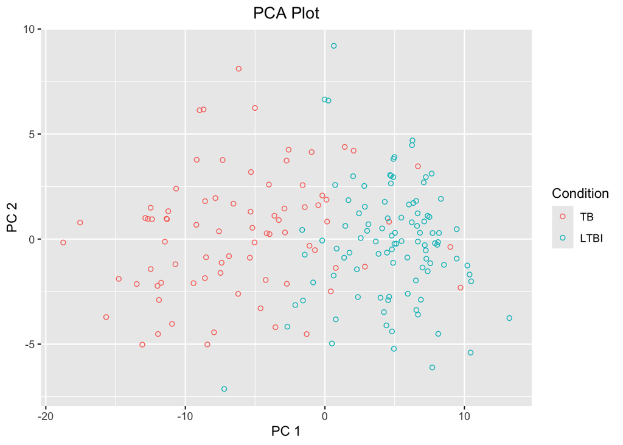

#### Step 1

```r
## Read in the data
TBnanostring <- readRDS("TBnanostring.rds")
```

#### Step 2

```r
## Read in the data
TBnanostring <- readRDS("TBnanostring.rds")

## Apply PCA
pca_out <- prcomp(TBnanostring[,-1])
```

#### Step 3

```r
## Read in the data
TBnanostring <- readRDS("TBnanostring.rds")

## Apply PCA
pca_out <- prcomp(TBnanostring[,-1])

## Make a dataframe with the results for plotting
pca_reduction <- as.data.frame(pca_out$x)
pca_reduction$Condition <- as.factor(TBnanostring$TB_Status)
```